# Expolatory Data Analysis : Visualisation

hp621@scarletmail.rutgers.edu

2/1/2023

Questions

1)Can we predict the popularity of a song with the help of Spotify audio features? 2)Can we predict the populairty using youtube main feature such as ‘views’,‘like’, ’comments? 3)Check the max and min vaue of dependent varaibles

```r
#Importing the data set
library(readr)
Spotify_Youtube <- read_csv("C:/Users/HARSH/Desktop/RU/SEM 2/MVA/Spotify_Youtube.csv")
```

```
## ──────────────────────────────────────────────────────── Delimiter: "," chr
## (10): Artist, Url_spotify, Track, Album, Album_type, Uri, Url_youtube, T... dbl
## (16): ...1, Danceability, Energy, Key, Loudness, Speechiness, Acousticne... lgl
## (2): Licensed, official_video
```

```r
View(Spotify_Youtube)
```

```r
Spotify_Youtube <- as.data.frame(Spotify_Youtube)

dependent_columns <- c(6,8:18, 22:24, 28)

Spotify_Youtube_new<- Spotify_Youtube[, dependent_columns]

Spotify_Youtube_new
```

[output not shown]

[output cut: 18736 more lines]

```r
summary(Spotify_Youtube_new)
```

```
##   Album_type         Danceability        Energy               Key
##  Length:20718       Min.   :0.0000   Min.   :0.0000203   Min.   : 0.0
##  Class :character   1st Qu.:0.5180   1st Qu.:0.5070000   1st Qu.: 2.0
##  Mode  :character   Median :0.6370   Median :0.6660000   Median : 5.0
##                     Mean   :0.6198   Mean   :0.6352503   Mean   : 5.3
##                     3rd Qu.:0.7402   3rd Qu.:0.7980000   3rd Qu.: 8.0
##                     Max.   :0.9750   Max.   :1.0000000   Max.   :11.0
##                     NA's   :2        NA's   :2           NA's   :2
##     Loudness        Speechiness       Acousticness       Instrumentalness
##  Min.   :-46.251   Min.   :0.00000   Min.   :0.0000011   Min.   :0.0000000
##  1st Qu.: -8.858   1st Qu.:0.03570   1st Qu.:0.0452000   1st Qu.:0.0000000
##  Median : -6.536   Median :0.05050   Median :0.1930000   Median :0.0000024
##  Mean   : -7.672   Mean   :0.09646   Mean   :0.2915353   Mean   :0.0559616
##  3rd Qu.: -4.931   3rd Qu.:0.10300   3rd Qu.:0.4772500   3rd Qu.:0.0004630
##  Max.   :  0.920   Max.   :0.96400   Max.   :0.9960000   Max.   :1.0000000
##  NA's   :2         NA's   :2         NA's   :2           NA's   :2
##     Liveness         Valence           Tempo        Duration_ms
##  Min.   :0.0145   Min.   :0.0000   Min.   :  0.0   Min.   :  30985
##  1st Qu.:0.0941   1st Qu.:0.3390   1st Qu.: 97.0   1st Qu.: 180010
##  Median :0.1250   Median :0.5370   Median :120.0   Median : 213284
##  Mean   :0.1935   Mean   :0.5299   Mean   :120.6   Mean   : 224718
##  3rd Qu.:0.2370   3rd Qu.:0.7262   3rd Qu.:139.9   3rd Qu.: 252443
##  Max.   :1.0000   Max.   :0.9930   Max.   :243.4   Max.   :4676058
##  NA's   :2        NA's   :2        NA's   :2       NA's   :2
##      Views               Likes             Comments            Stream
##  Min.   :0.000e+00   Min.   :       0   Min.   :       0   Min.   :6.574e+03
##  1st Qu.:1.826e+06   1st Qu.:   21581   1st Qu.:     509   1st Qu.:1.767e+07
##  Median :1.450e+07   Median :  124481   Median :    3277   Median :4.968e+07
##  Mean   :9.394e+07   Mean   :  663341   Mean   :   27519   Mean   :1.359e+08
##  3rd Qu.:7.040e+07   3rd Qu.:  522148   3rd Qu.:   14360   3rd Qu.:1.384e+08
##  Max.   :8.080e+09   Max.   :50788652   Max.   :16083138   Max.   :3.387e+09
##  NA's   :470         NA's   :541        NA's   :569        NA's   :576
```

```r
#Data cleaning
Spotify_Youtube_new[!complete.cases(Spotify_Youtube_new), ]
```

[output not shown]

[output cut: 3495 more lines]

```r
sapply(Spotify_Youtube_new, function(x) mean(is.na(x)) * 100)
```

```
##       Album_type     Danceability           Energy              Key
##      0.000000000      0.009653441      0.009653441      0.009653441
##         Loudness      Speechiness     Acousticness Instrumentalness
##      0.009653441      0.009653441      0.009653441      0.009653441
##         Liveness          Valence            Tempo      Duration_ms
##      0.009653441      0.009653441      0.009653441      0.009653441
##            Views            Likes         Comments           Stream
##      2.268558741      2.611255913      2.746404093      2.780191138
```

```r
Spotify_Youtube_new <- na.omit(Spotify_Youtube_new)
```

#Dependent Variables

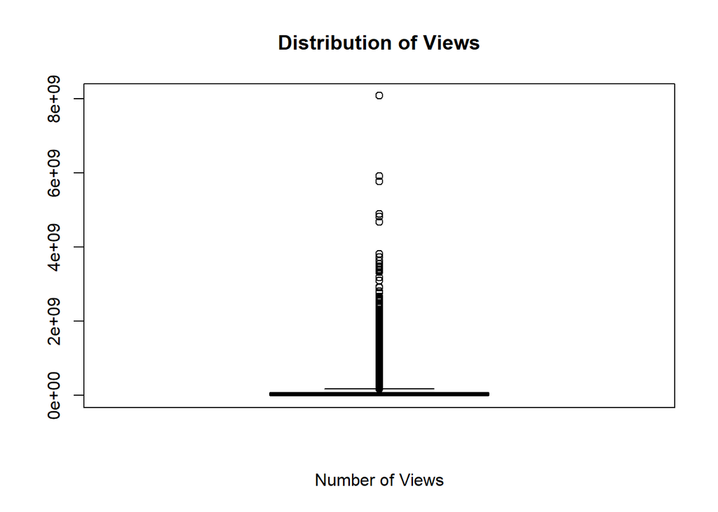

```r
boxplot(Spotify_Youtube_new$Views, main = "Distribution of Views", xlab = "Number of Views", col = "skyblue")
```

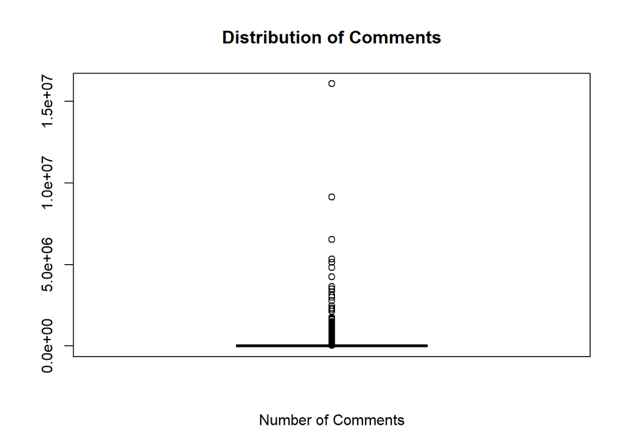

```r
boxplot(Spotify_Youtube_new$Comments, main = "Distribution of Comments", xlab = "Number of Comments",col = "skyblue")
```

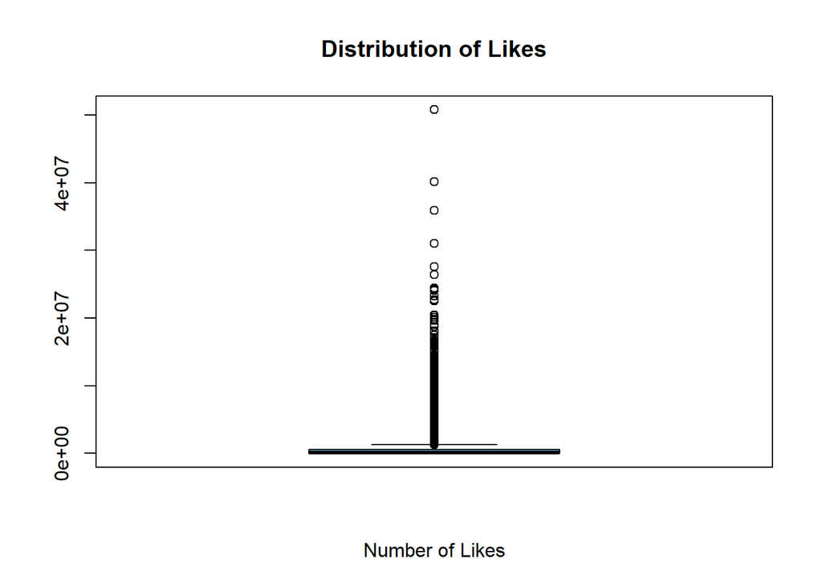

```r
boxplot(Spotify_Youtube_new$Likes, main = "Distribution of Likes", xlab = "Number of Likes",col = "skyblue")
```

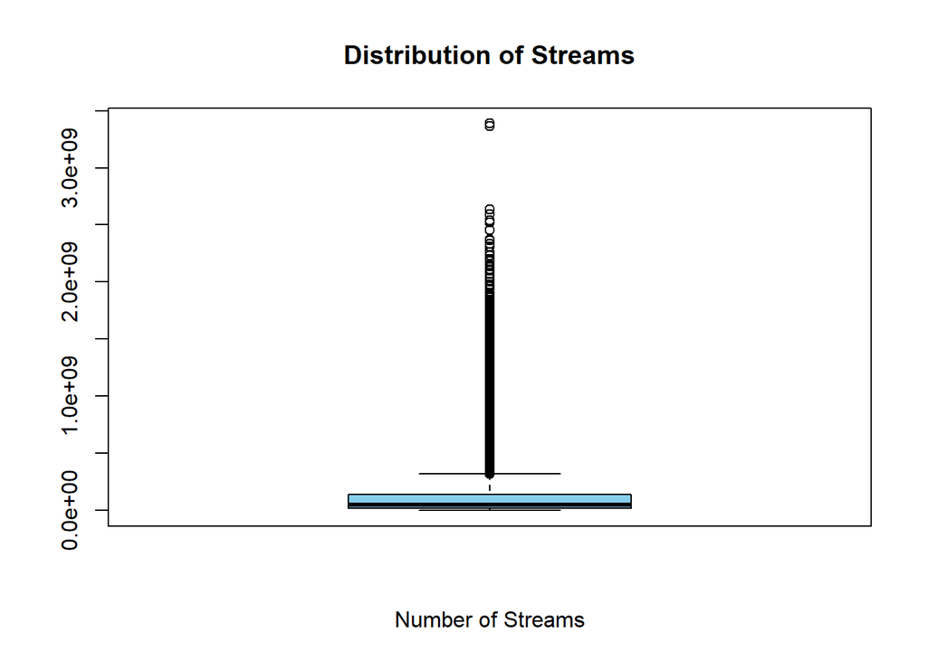

```r
boxplot(Spotify_Youtube_new$Stream, main = "Distribution of Streams", xlab = "Number of Streams",col = "skyblue")
```

The boxplots again show that the outliers seem to be heavily influencing the distributions thus I will consider omitting them.

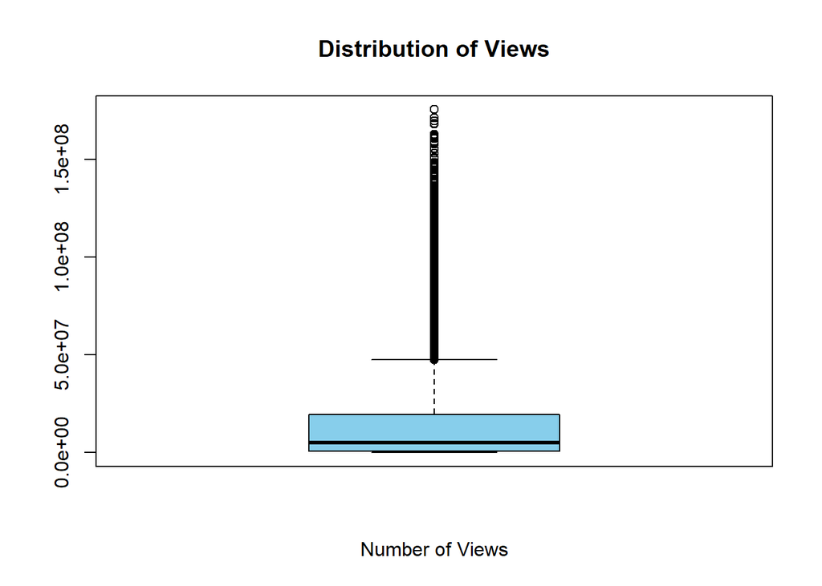

```r
Spotify_Youtube_new_dep <- Spotify_Youtube_new[, 13:16]

Spotify_Youtube_new_clean <- Spotify_Youtube_new

for (col in colnames(Spotify_Youtube_new_dep)) {
  Q1 <- quantile(Spotify_Youtube_new_clean[[col]], 0.25, na.rm = TRUE)
  Q3 <- quantile(Spotify_Youtube_new_clean[[col]], 0.75, na.rm = TRUE)
  IQR <- Q3 - Q1

  outliers <- Spotify_Youtube_new_clean[[col]] < (Q1 - 1.5 * IQR) | Spotify_Youtube_new_clean[[col]] > (Q3 + 1.5 * IQR)

  Spotify_Youtube_new_clean <- Spotify_Youtube_new_clean[!outliers, ]
}


boxplot(Spotify_Youtube_new_clean$Views, main = "Distribution of Views", xlab = "Number of Views", col = "skyblue")
```

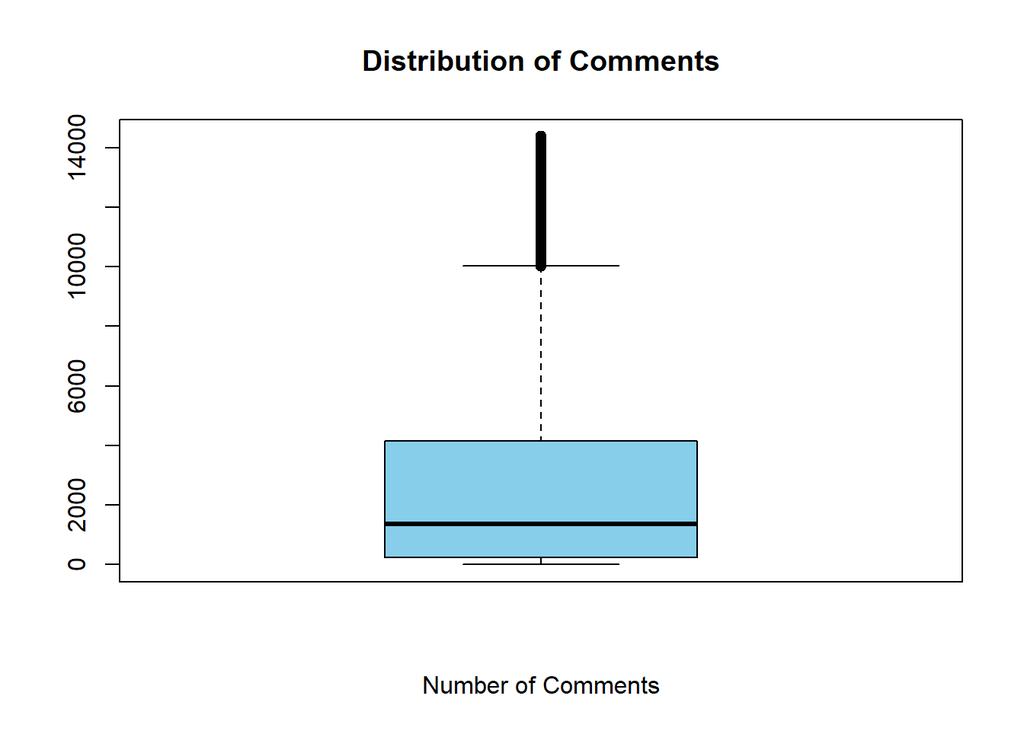

```r
boxplot(Spotify_Youtube_new_clean$Comments, main = "Distribution of Comments", xlab = "Number of Comments",col = "skyblue")
```

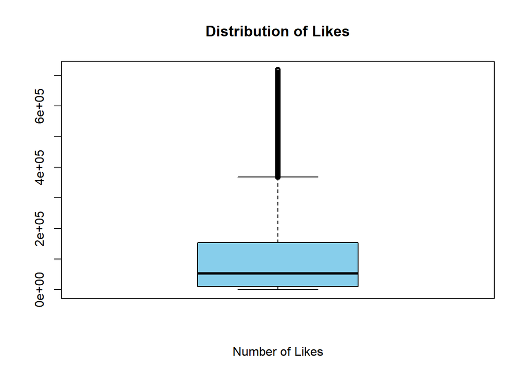

```r
boxplot(Spotify_Youtube_new_clean$Likes, main = "Distribution of Likes", xlab = "Number of Likes",col = "skyblue")
```

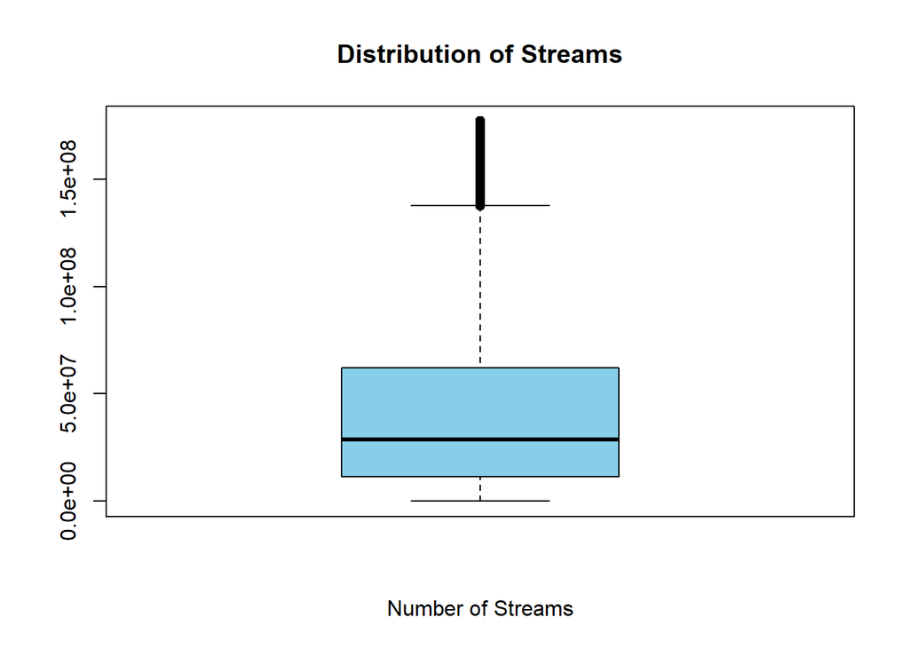

```r
boxplot(Spotify_Youtube_new_clean$Stream, main = "Distribution of Streams", xlab = "Number of Streams",col = "skyblue")
```

The distributions are easier to visualize now; however, they are still all right skewed which will have some implications with the assumptions of the analyses and models we plan to perform.

```r
#Max and Min
max_Views <- max(Spotify_Youtube_new$Views, na.rm = TRUE)
min_Views <- min(Spotify_Youtube_new$Views, na.rm = TRUE)
cat("Maximum Views:",max_Views , "\n")
```

```
## Maximum Views: 8079649362
```

```r
cat("Minimum Views:",min_Views , "\n")
```

```
## Minimum Views: 26
```

```r
max_Comments <- max(Spotify_Youtube_new$Comments, na.rm = TRUE)
min_Comments <- min(Spotify_Youtube_new$Comments, na.rm = TRUE)
cat("Maximum Comments :",max_Comments , "\n")
```

```
## Maximum Comments : 16083138
```

```r
cat("Minimum Comments:",min_Comments , "\n")
```

```
## Minimum Comments: 0
```

```r
max_Likes <- max(Spotify_Youtube_new$Likes, na.rm = TRUE)
min_Likes <- min(Spotify_Youtube_new$Likes, na.rm = TRUE)
cat("Maximum Likes :",max_Likes , "\n")
```

```
## Maximum Likes : 50788652
```

```r
cat("Minimum Likes:",min_Likes , "\n")
```

```
## Minimum Likes: 0
```

```r
max_Streams <- max(Spotify_Youtube_new$Stream, na.rm = TRUE)
min_Streams <- min(Spotify_Youtube_new$Stream, na.rm = TRUE)
cat("Maximum Streams :",max_Streams , "\n")
```

```
## Maximum Streams : 3386520288
```

```r
cat("Minimum Streams:",min_Streams , "\n")
```

```
## Minimum Streams: 6574
```

##Independent Variables

```r
library(dplyr)
```

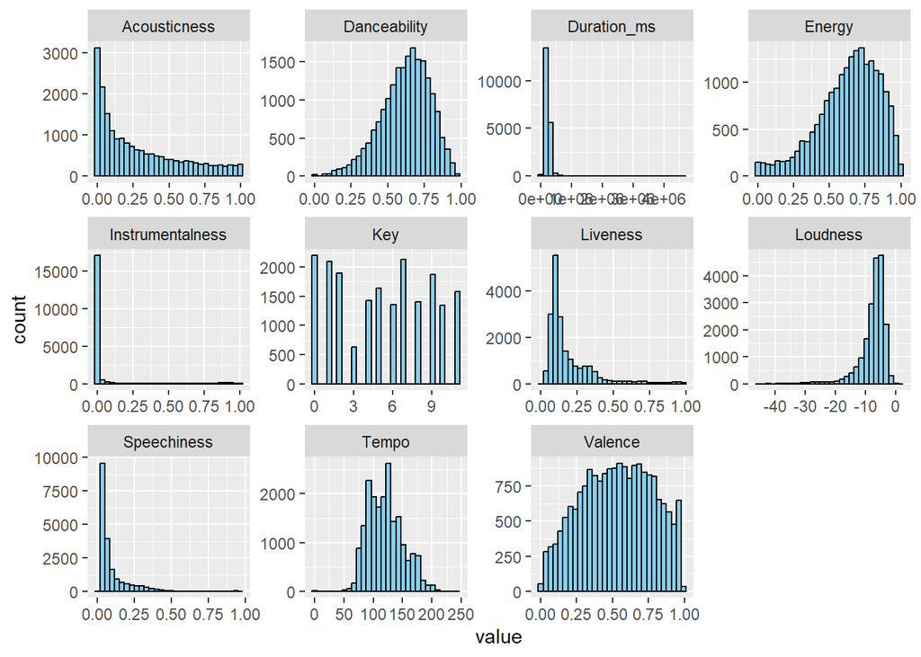

```r
library(ggplot2)
library(tidyr)


Spotify_Youtube_new %>%
  select(2:12) %>%
  pivot_longer(everything()) %>%
  ggplot(aes(x = value))+
  geom_histogram(bins = 30, color = "black", fill = "skyblue") +
  facet_wrap(~name, scales = "free")
```

From the histograms we see that Acousticeness is right skewed, Liveness is right skewed, Loudness is left skewed, Speechiness is right skewed, and Duration_ms and Instrumentalness seem to be heavily influenced by extreme outliers in regards to their skewness.

Key is represeneted as a numerical variable within the dataset. It is a descrete numerical variable, but it is also a categorical variable. In music theory, the difference between the keys is not numerical but categorical thus it should be treated as a factor rather than a numeric variable within a regression model.

In regards to Duration_ms and Instrumentalness, we will not remove these extreme outliers. For duration_ms , it is plausible that there might be some very long songs. For Instrumentalness, there are songs that are completely instrumental. These can be valuable in terms of understanding the relationships between variables. Since linear regression models can be highly sensitive to outliers, we will consider using a log-transformation to minimize the impact of these extreme values.

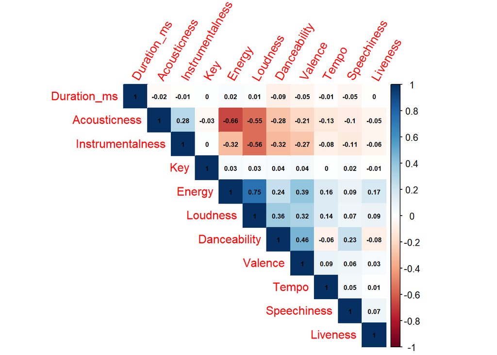

```r
library(corrplot)
corr_plot_data <- Spotify_Youtube_new %>% select(Danceability, Energy, Key, Loudness, Speechiness, Acousticness,Instrumentalness, Liveness, Valence, Tempo, Duration_ms)

corr_matrix <- cor(corr_plot_data)

corrplot(corr_matrix,
         method = "color",
         type = "upper",
         order = "hclust",
         diag = TRUE,
         addCoef.col = TRUE,
         number.cex = 0.55,
         tl.srt = 60)
```

From the correlation plot, we can see some trends at a glance. Acousticness seems to be negatively correlated with several variables, especially Energy and Loudness.

Intrumentalness also seems to be negatively correlation with several variables except Acousticness.

Energy seems to have a positive correlation between Loudness, and Valence. The relationship with `Loudness` is predictable, however it’s interesting to see that a song with higher energy is correlated with higher positivity.